# IS 451 Multiple Linear Regression Tutorial

## Outline:

1. Demo: Toyota cars
2. Practice: Takyo Software Data

## Demo: Toyota cars

### Data Description

A large Toyota car dealership offers purchasers of new Toyota cars the option to buy their used car as part of a trade-in. In particular, a new promotion promises to pay high prices for used Toyota Corolla cars for purchasers of a new car. The dealer then sells the used cars for a small profit. To ensure a reasonable profit, the dealer needs to be able to predict the price that the dealerhsip will get for the used cars. For that reason, data were collected on all previous sales of used Toyato Corollas at the dealership. The file `ToyotaCorolla.csv` includes the sales price and other information on the car, such as its ae, mileage, fuel type, and engine size.

### Read and select data

```r
#read data
toyota.df <- read.csv("ToyotaCorolla.csv", stringsAsFactors = TRUE)
```

### Choose predictors

Based on your business understanding and exploratory data analysis, choose predictors that might have a (linear) impact on the target variable.

#### Draw scatter plots

You can, for example, draw several scatter plots to explore the relationship between your target variable and each of your predictors.

#### Check correlations

Or, you can simply check correlations. Correlations is a statistical measure that suggests the level of linear dependence between two variables. Correlation can take values between -1 and +1. A value closer to 0, e.g. (-0.2, 0.2) suggests a week relationship between the variables.

```r
cor(toyota.df$KM, toyota.df$Price)
```

```
## [1] -0.5699602
```

```r
cor(toyota.df$Doors, toyota.df$Price)
```

```
## [1] 0.1853255
```

#### Select predictors for regression

```r
# select variables for regression
selected.var <- c(3, 4, 7, 8, 9, 10, 12, 13, 14, 17, 18)
car.df <- toyota.df[, selected.var]
#View(car.df) # verify that columns are correct
```

### Fit a multiple linear regression for Price

#### Step 1: Partition the records into `70%` training vs. `30%` validation with the seed set to 1.

To create a train and validation set, we are going to split randomly this data set into 70% training set and 30% validation set.

We point out the observations we want to include in the training set by randomly sample 70% $\times$ `nrow(car.df)` indexes out of `nrow(car.df)` observations.

Use `?sample` to see the documentation.

```r
set.seed(1)  # set seed for reproducing the partition
# Random sample indexes
train.index <- sample(1:nrow(car.df), nrow(car.df)*0.7)
```

Then, we can build the training and validation set.

```r
# Build training and validation set by indexing
train.df <- car.df[train.index, ]
valid.df <- car.df[-train.index, ]
```

#### Step 2: Multiple linear regression

Linear model is the most popular model for making predictions.

We are trying to find the parameters $\beta$s which can best describe a continuous response variable $Y$ as a function of one or more predictor variables $X$.

Basic formula:
$$\begin{equation}
Y = \beta_0 + \beta_1x_1 +\beta_2x_2 + \beta_2x_2 + \dots + \beta_px_p +
\epsilon
\end{equation}$$

Run a multiple linear regression for `Price` vs. `all selected predictors` using `lm` function.

```r
# use lm() to run a linear regression of Spending on all 6 predictors in the training set
car.lm <- lm(Price~., data = train.df)
```

Here `~` represents formula in R.

- `Y ~ X`: `Y` target, `X` predictors.
- `Price ~ .`: Price target, use all the other variables in the data frame (`train.df`) as the predictors
- `Price ~ KM + Age_08_04`: Use only `KM` and `Age_08_04` as the predictors
- `Price ~ KM:Age_08_04`: Use the interation between `KM` and `Age_08_04`
- `Price ~ Weight + KM:Age_08_04`

Display the results

```r
#  use options() to ensure numbers are not displayed in scientific notation.
options(scipen = 999, digits=3)
summary(car.lm)
```

```
##
## Call:
## lm(formula = Price ~ ., data = train.df)
##
## Residuals:
##    Min     1Q Median     3Q    Max
## -10973   -770    -32    756   6882
##
## Coefficients:
##                    Estimate  Std. Error t value             Pr(>|t|)
## (Intercept)     -7290.86354  1389.48294   -5.25      0.0000001888073 ***
## Age_08_04        -124.50823     3.17401  -39.23 < 0.0000000000000002 ***
## KM                 -0.01634     0.00163  -10.01 < 0.0000000000000002 ***
## Fuel_TypeDiesel  1195.55454   484.45156    2.47                0.014 *
## Fuel_TypePetrol  2953.52753   468.80795    6.30      0.0000000004464 ***
## HP                 28.92328     4.27362    6.77      0.0000000000223 ***
## Met_Color         125.46530    90.63065    1.38                0.167
## Automatic         317.28221   195.78759    1.62                0.105
## CC                 -0.02809     0.09259   -0.30                0.762
## Doors             -74.99725    47.37553   -1.58                0.114
## Quarterly_Tax      14.23726     2.04097    6.98      0.0000000000055 ***
## Weight             18.10724     1.35484   13.36 < 0.0000000000000002 ***
## ---
## Signif. codes:  0 '***' 0.001 '**' 0.01 '*' 0.05 '.' 0.1 ' ' 1
##
## Residual standard error: 1330 on 993 degrees of freedom
## Multiple R-squared:  0.874,  Adjusted R-squared:  0.873
## F-statistic:  626 on 11 and 993 DF,  p-value: <0.0000000000000002
```

#### Step 3: Intepret the coefficients.

lm() automatically convert Fuel variable to dummies and drop one! The reason is that Fuel is a factor in R after read.csv().

- `Estimates`: the value for the $\beta$s in our model.
- `Std. Error`: the estimation precision of the coefficient
- `Pr(>|t|)`: P-value measures how likely the coefficient has no effect on the outcome

Interpreting the coffecients for `Age_08_04` and `Fuel_Type`:

- `Age_08_04`: When age increases by one unit, the price drops by $124.50 (with else being equal)
- `Fuel_Type` :
  - Fuel: {“Diesel”, “Petrol”, “CNG”}
  - Fuel_TypeCNG: base level
  - Comparing to CNG, a car with Diesel is sold $1195.55 more (with else being equal)

#### Step 4: Make predictions for any data.

- Use `predict` function to make predictions of any data set

```r
# use predict() to make predictions on a new set.
car.lm.pred <- predict(car.lm, valid.df)
```

#### Step 5: Evaluate the predictive accuracy of the model by examining its performance on the validation set.

- We need to use library `forecast`. Then Use `accuracy` to compute common accuracy measures.

Recall different accuracy measures:
$$ME:
= {1 \over n}\sum\limits_{i = 1}^n {({Y_i} - {\hat{Y}_i}) = } {1 \over
n}\sum\limits_{i = 1}^n {{e_i}}$$
$$MAE: = {1 \over n}\sum\limits_{i = 1}^n {|{e_i}}
|$$

$$RMSE: = \sqrt {{1 \over n}\sum\limits_{i
= 1}^n {e_i^2} }$$

Load library

```r
library(forecast)
```

Calculate the prediction accuracy using `accuracy` function.

```r
#  use options() to ensure numbers are not displayed in scientific notation.
options(scipen=999, digits = 3)

# use accuracy() to compute common accuracy measures.
accuracy(car.lm.pred, valid.df$Price)
```

```
##            ME RMSE  MAE   MPE MAPE
## Test set 92.8 1290 1008 0.116   10
```

## Practice: Takyo Software Data

Takyo software catalog firm that sells games and educational software. It started out as a software manufacturer and then added third-party titles to its offerings. It recently revised its collection of items in a new catalog, which it mailed out to its customers. The file `Tayko.csv` contains information on 2000 purchase.

Based on these data and variables, Takyo wants to devise a model for predicting the spending amount that a purchasing customer will yield.

The next table describes the predictors to be used in the problem (the csv file contains additional variables).

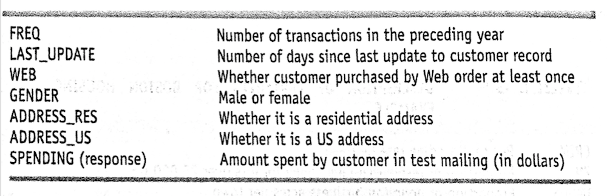

### Question 1

- Explore the relationship between spending and each of the two continuous predictors by creating two scatterplots (Spending vs. Freq and Spending vs. last_update_days_ago). Does there seem to be a linear relationship?

### Question 2

- Partition the data into 80% training vs. 20% validation with the seed set to 123
- Run a multiple linear regression for Spending vs. all six predictors. Write down the fitted predictive equation.
- Examine and interpret the coefficients. What do you find?

### Question 3

- Evaluate the predictive accuracy (RMSE) on the `training set`
- Evaluate the predictive accuracy (RMSE) on the `validation set`